# Case 31: Reliability and Factor Analysis

Employee proficiency and operational effectiveness

Author

Simran Kaur

Published

November 8, 2026

# Overview

Before combining survey items, I checked whether they measure one underlying idea and whether they are internally consistent. This report reviews **employee proficiency (Q3–Q6)** and **operational effectiveness (Q31–Q34)** using the results saved in the original report.

# Process and Key Findings

## 1. Check whether the items belong together

I reviewed the correlations, KMO and Bartlett’s test. The employee items showed stronger shared relationships, with **KMO = .78**. The operations items had **KMO = .50**, suggesting weak support for factor analysis. Bartlett’s test was significant for both sets, but significance alone does not establish a useful scale.

## 2. Examine the factor structure

The employee items supported one factor. Their loadings ranged from **.73 to .93**, and the factor explained approximately **63% of the variance**. Some fit statistics were less reassuring, so I would interpret the structure alongside the loadings and item wording rather than describe the fit as uniformly good.

For operations, the one-factor model was dominated by Q32. The remaining loadings were only **.23–.39**, while Q32 loaded near **1.00** with very low uniqueness. That boundary estimate calls for caution, even though the overall fit indices looked acceptable.

The saved parallel-analysis output suggested **two factors for operations**, contrary to the original explanation. However, an unrestricted two-factor EFA with only four items is not adequately identified, so I would not use that model to justify separate subscales. Parallel analysis also uses simulation; setting a seed makes future runs reproducible.

## 3. Check reliability and choose the measure

| Measure | KMO | Cronbach’s alpha | Decision |
| --- | --- | --- | --- |
| Employee proficiency: Q3–Q6 | .78 | **.87** | Combine into an employee index. |
| Operational effectiveness: Q31–Q34 | .50 | **.47** | Analyze the four items separately. |

Dropping an employee item lowered alpha. Dropping an operations item did not bring reliability close to .70. The wording supports the same decision: courtesy, helpfulness, professionalism and availability describe staff proficiency, while privacy, speed, service fit and application simplicity are different operational judgments.

# Implications for the Next Analysis

I will use the mean of Q3–Q6 for **R3** and the residence comparison in **R4a**. For **R6 and R4c**, I will keep Q31–Q34 separate. This four-item operations result (α = .47) differs from the earlier five-item Q30–Q34 analysis (α ≈ .54); they are different item sets.

Any one-sample t-test needs a stated comparison value. Residence comparisons involve independent groups, and testing several operations items requires attention to multiple comparisons.

# R Code

Code is grouped below; lengthy output and plots are hidden. The summaries above describe the supplied report’s saved results. Seeded parallel-analysis reruns may differ from its original unseeded run.

**Setup and checks**

**Show R code**

```r
library(tidyverse)
library(haven)
library(psych)
library(GPArotation)
library(knitr)
options(knitr.kable.NA = "")

if (!file.exists("Case 31 Data_efcu_4.sav")) {
  stop("Place Case 31 Data_efcu_4.sav beside this QMD before rendering.")
}
efcu <- read_sav("Case 31 Data_efcu_4.sav")
d    <- zap_labels(efcu)

r3_items <- c("q3", "q4", "q5", "q6")
r6_items <- c("q31", "q32", "q33", "q34")

r3 <- as.data.frame(d[, r3_items])
r6 <- as.data.frame(d[, r6_items])

item_labels <- c(
  q3  = "Q3: Employees are courteous",
  q4  = "Q4: Employees are helpful",
  q5  = "Q5: Employees are professional",
  q6  = "Q6: Employees are available",
  q31 = "Q31: Personnel keep info confidential",
  q32 = "Q32: Prompt in processing loans",
  q33 = "Q33: Services meet members' needs",
  q34 = "Q34: Loan applications simple"
)
```

**Show R code**

```r
# Screening summary: KMO + Bartlett + eigenvalues
screen_scale <- function(x) {
  k  <- KMO(x)
  b  <- cortest.bartlett(cor(x), n = nrow(x))
  ev <- eigen(cor(x))$values
  list(kmo = k, bartlett = b, eigen = ev)
}

# Loadings table from a one-factor ML solution
loading_table <- function(f, x) {
  tibble(
    Item        = item_labels[colnames(x)],
    Loading     = f$loadings[, 1],
    Communality = f$communality,
    Uniqueness  = f$uniquenesses
  )
}

# Alpha item table
alpha_table <- function(a, x) {
  tibble(
    Item             = item_labels[colnames(x)],
    Mean             = a$item.stats$mean,
    SD               = a$item.stats$sd,
    `r.drop`         = a$item.stats$r.drop,
    `Alpha if dropped` = a$alpha.drop$raw_alpha
  )
}
```

**Employee proficiency**

**Show R code**

```r
cor(r3) |> round(2) |> kable()
```

Table 1: R3 inter-item correlations

|  | q3 | q4 | q5 | q6 |
| --- | --- | --- | --- | --- |
| q3 | 1.00 | 0.72 | 0.57 | 0.46 |
| q4 | 0.72 | 1.00 | 0.68 | 0.67 |
| q5 | 0.57 | 0.68 | 1.00 | 0.64 |
| q6 | 0.46 | 0.67 | 0.64 | 1.00 |

**Show R code**

```r
r3_screen <- screen_scale(r3)
r3_screen$kmo
```

```
Kaiser-Meyer-Olkin factor adequacy
Call: KMO(r = x)
Overall MSA =  0.78
MSA for each item =
  q3   q4   q5   q6
0.76 0.73 0.84 0.79
```

**Show R code**

```r
r3_screen$bartlett
```

```
$chisq
[1] 263.6114

$p.value
[1] 5.045872e-54

$df
[1] 6
```

**Show R code**

```
Parallel analysis suggests that the number of factors =  1  and the number of components =  NA
```

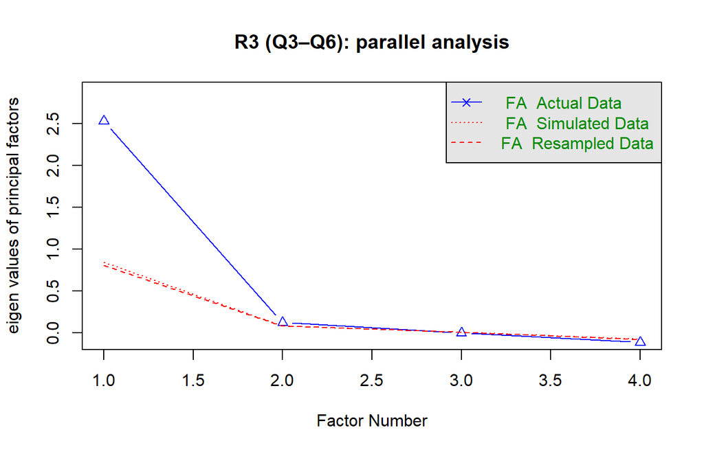

Figure 1: R3 parallel analysis and scree plot

```r
set.seed(3103)
r3_pa <- fa.parallel(r3, fm = "ml", fa = "fa", main = "R3 (Q3–Q6): parallel analysis")
```

**Show R code**

```r
r3_fa <- fa(r3, nfactors = 1, fm = "ml", rotate = "none")
print(r3_fa, digits = 3)
```

```
Factor Analysis using method =  ml
Call: fa(r = r3, nfactors = 1, rotate = "none", fm = "ml")
Standardized loadings (pattern matrix) based upon correlation matrix
     ML1    h2    u2 com
q3 0.754 0.569 0.431   1
q4 0.927 0.859 0.141   1
q5 0.760 0.577 0.423   1
q6 0.726 0.527 0.473   1

                 ML1
SS loadings    2.531
Proportion Var 0.633

Mean item complexity =  1
Test of the hypothesis that 1 factor is sufficient.

df null model =  6  with the objective function =  2.112 with Chi Square =  263.611
df of  the model are 2  and the objective function was  0.091

The root mean square of the residuals (RMSR) is  0.051
The df corrected root mean square of the residuals is  0.089

The harmonic n.obs is  128 with the empirical chi square  2.031  with prob <  0.362
The total n.obs was  128  with Likelihood Chi Square =  11.346  with prob <  0.00344

Tucker Lewis Index of factoring reliability =  0.8906
RMSEA index =  0.1909  and the 90 % confidence intervals are  0.0941 0.3068
BIC =  1.642
Fit based upon off diagonal values = 0.993
Measures of factor score adequacy
                                                    ML1
Correlation of (regression) scores with factors   0.953
Multiple R square of scores with factors          0.908
Minimum correlation of possible factor scores     0.816
```

**Show R code**

```r
loading_table(r3_fa, r3) |> kable(digits = 3)
```

Table 2: R3 one-factor ML solution

| Item | Loading | Communality | Uniqueness |
| --- | --- | --- | --- |
| Q3: Employees are courteous | 0.754 | 0.569 | 0.431 |
| Q4: Employees are helpful | 0.927 | 0.859 | 0.141 |
| Q5: Employees are professional | 0.760 | 0.577 | 0.423 |
| Q6: Employees are available | 0.726 | 0.527 | 0.473 |

**Show R code**

```r
r3_alpha <- alpha(r3)
r3_alpha$total |> kable(digits = 3)
```

|  | raw_alpha | std.alpha | G6(smc) | average_r | S/N | ase | mean | sd | median_r |
| --- | --- | --- | --- | --- | --- | --- | --- | --- | --- |
|  | 0.866 | 0.869 | 0.85 | 0.624 | 6.645 | 0.019 | 4.205 | 0.594 | 0.655 |

**Show R code**

```r
alpha_table(r3_alpha, r3) |> kable(digits = 3)
```

Table 3: R3 item-total statistics

| Item | Mean | SD | r.drop | Alpha if dropped |
| --- | --- | --- | --- | --- |
| Q3: Employees are courteous | 4.352 | 0.659 | 0.657 | 0.852 |
| Q4: Employees are helpful | 4.312 | 0.696 | 0.823 | 0.785 |
| Q5: Employees are professional | 4.078 | 0.659 | 0.733 | 0.824 |
| Q6: Employees are available | 4.078 | 0.790 | 0.673 | 0.853 |

**Show R code**

```r
employee_index <- rowMeans(r3, na.rm = TRUE)
employee_index[is.nan(employee_index)] <- NA_real_
if ("Att_employee" %in% names(d)) {
  all.equal(employee_index, as.numeric(d$Att_employee))
}
```

```
[1] TRUE
```

**Operational effectiveness**

**Show R code**

```r
cor(r6) |> round(2) |> kable()
```

Table 4: R6 inter-item correlations

|  | q31 | q32 | q33 | q34 |
| --- | --- | --- | --- | --- |
| q31 | 1.00 | 0.28 | 0.12 | 0.00 |
| q32 | 0.28 | 1.00 | 0.22 | 0.39 |
| q33 | 0.12 | 0.22 | 1.00 | 0.04 |
| q34 | 0.00 | 0.39 | 0.04 | 1.00 |

**Show R code**

```r
r6_screen <- screen_scale(r6)
r6_screen$kmo
```

```
Kaiser-Meyer-Olkin factor adequacy
Call: KMO(r = x)
Overall MSA =  0.5
MSA for each item =
 q31  q32  q33  q34
0.49 0.50 0.60 0.46
```

**Show R code**

```r
r6_screen$bartlett
```

```
$chisq
[1] 39.33432

$p.value
[1] 6.15472e-07

$df
[1] 6
```

**Show R code**

```
Parallel analysis suggests that the number of factors =  2  and the number of components =  NA
```

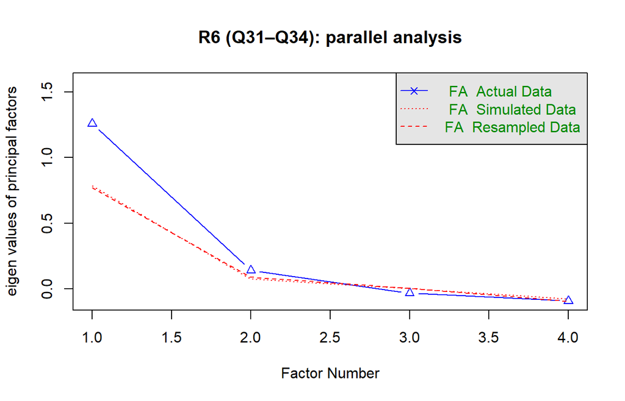

Figure 2: R6 parallel analysis and scree plot

```r
set.seed(3106)
r6_pa <- fa.parallel(r6, fm = "ml", fa = "fa", main = "R6 (Q31–Q34): parallel analysis")
```

**Show R code**

```r
r6_fa <- fa(r6, nfactors = 1, fm = "ml", rotate = "none")
print(r6_fa, digits = 3)
```

```
Factor Analysis using method =  ml
Call: fa(r = r6, nfactors = 1, rotate = "none", fm = "ml")
Standardized loadings (pattern matrix) based upon correlation matrix
      ML1     h2    u2 com
q31 0.279 0.0777 0.922   1
q32 0.997 0.9950 0.005   1
q33 0.225 0.0505 0.949   1
q34 0.389 0.1512 0.849   1

                 ML1
SS loadings    1.274
Proportion Var 0.319

Mean item complexity =  1
Test of the hypothesis that 1 factor is sufficient.

df null model =  6  with the objective function =  0.315 with Chi Square =  39.334
df of  the model are 2  and the objective function was  0.02

The root mean square of the residuals (RMSR) is  0.052
The df corrected root mean square of the residuals is  0.091

The harmonic n.obs is  128 with the empirical chi square  2.102  with prob <  0.35
The total n.obs was  128  with Likelihood Chi Square =  2.474  with prob <  0.29

Tucker Lewis Index of factoring reliability =  0.9571
RMSEA index =  0.0423  and the 90 % confidence intervals are  0 0.187
BIC =  -7.23
Fit based upon off diagonal values = 0.944
Measures of factor score adequacy
                                                    ML1
Correlation of (regression) scores with factors   0.998
Multiple R square of scores with factors          0.995
Minimum correlation of possible factor scores     0.990
```

**Show R code**

```r
loading_table(r6_fa, r6) |> kable(digits = 3)
```

Table 5: R6 one-factor ML solution

| Item | Loading | Communality | Uniqueness |
| --- | --- | --- | --- |
| Q31: Personnel keep info confidential | 0.279 | 0.078 | 0.922 |
| Q32: Prompt in processing loans | 0.997 | 0.995 | 0.005 |
| Q33: Services meet members’ needs | 0.225 | 0.051 | 0.949 |
| Q34: Loan applications simple | 0.389 | 0.151 | 0.849 |

**Show R code**

```r
r6_alpha <- alpha(r6)
r6_alpha$total |> kable(digits = 3)
```

|  | raw_alpha | std.alpha | G6(smc) | average_r | S/N | ase | mean | sd | median_r |
| --- | --- | --- | --- | --- | --- | --- | --- | --- | --- |
|  | 0.472 | 0.462 | 0.44 | 0.177 | 0.858 | 0.075 | 3.68 | 0.458 | 0.173 |

**Show R code**

```r
alpha_table(r6_alpha, r6) |> kable(digits = 3)
```

Table 6: R6 item-total statistics

| Item | Mean | SD | r.drop | Alpha if dropped |
| --- | --- | --- | --- | --- |
| Q31: Personnel keep info confidential | 3.945 | 0.679 | 0.195 | 0.467 |
| Q32: Prompt in processing loans | 3.719 | 0.793 | 0.495 | 0.144 |
| Q33: Services meet members’ needs | 3.594 | 0.681 | 0.187 | 0.473 |
| Q34: Loan applications simple | 3.461 | 0.783 | 0.229 | 0.445 |

# Reflection

The most useful part for me was seeing why a group of questions should not automatically become one score. Both sets use agreement scales, but only the employee items showed enough consistency to support combining them.

The operations results also reminded me to check the output against my explanation. A significant test or a good fit statistic is not enough on its own. I need to consider the loadings, reliability and what the questions actually ask before deciding how to use them.

# Appendix: Links

- [GitHub Pages report](https://simrank-dm.github.io/IBM6500-F26/IC-Case%2031/IC-Case31-Reliability%20%26%20factor%20analysis-R3%20%26%20R6/IC-Case31-Reliability-Factor-Analysis-R3%20%26%20R6-Simran-Kaur.html)
- [GitHub source folder](https://github.com/Simrank-DM/IBM6500-F26/tree/main/IC-Case%2031/IC-Case31-Reliability%20%26%20factor%20analysis-R3%20%26%20R6)